# Produto 2 - Survey. Material suplementar.

### Atuantes como profissionais de RIG *vs*. não atuantes

#### 1.1. Diferenças de médias (binárias)

As imagens abaixo ilustram, na forma de porcentagem, a diferença entre as médias dos respondentes que afirmaram atuar como profissionais de RIG face os que afirmaram não atuar. Na primeira imagem, por exemplo, observamos que 100% dos *não* atuantes afirmaram ser a favor da regulamentação do lobby; ao passo que 82% dos atuantes afirmaram o mesmo.

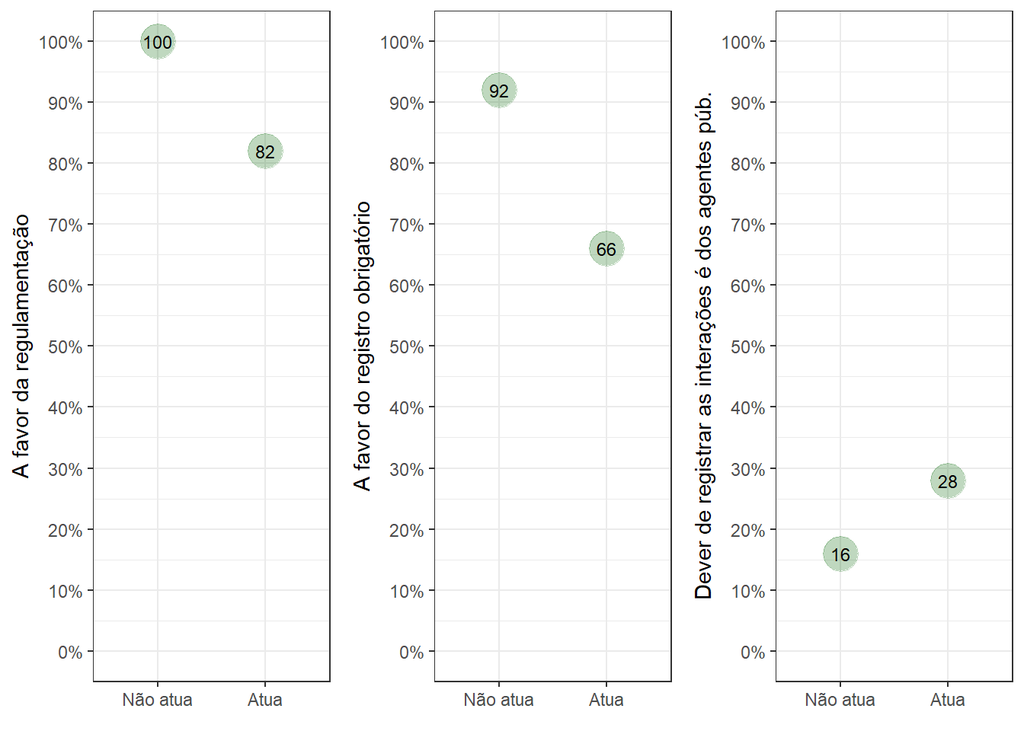

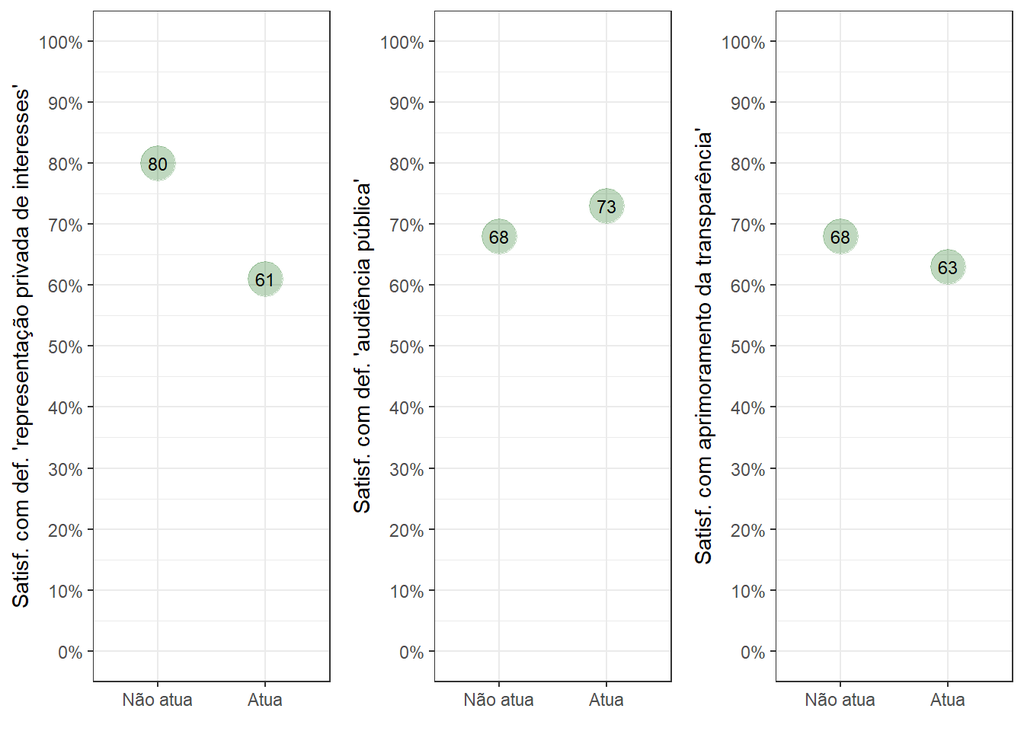

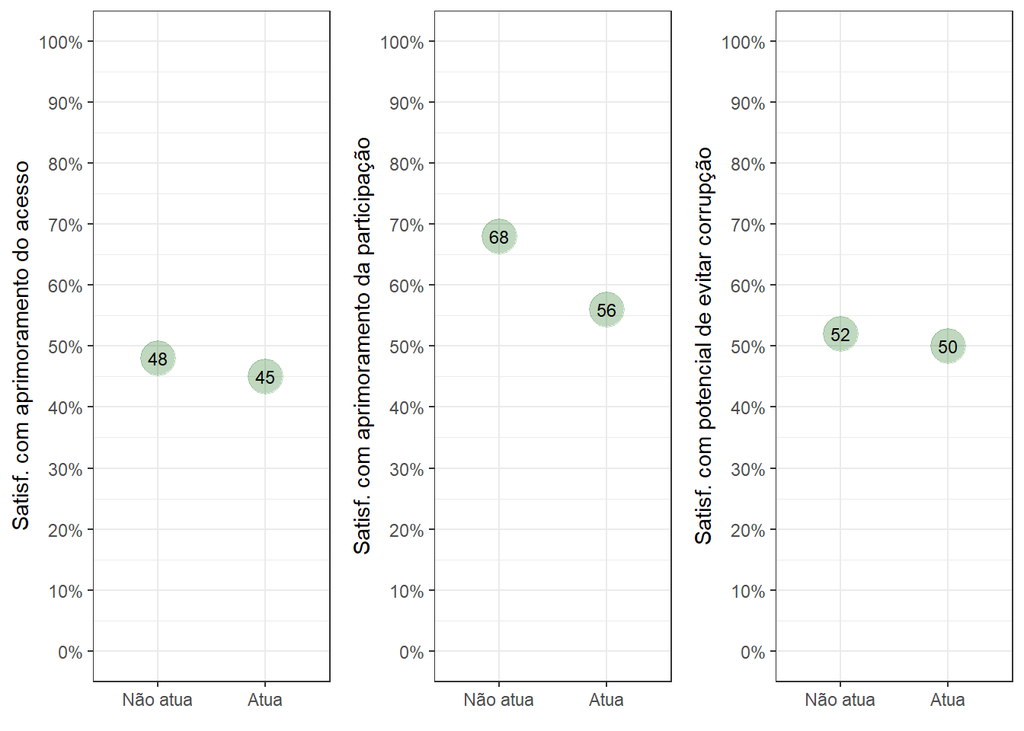

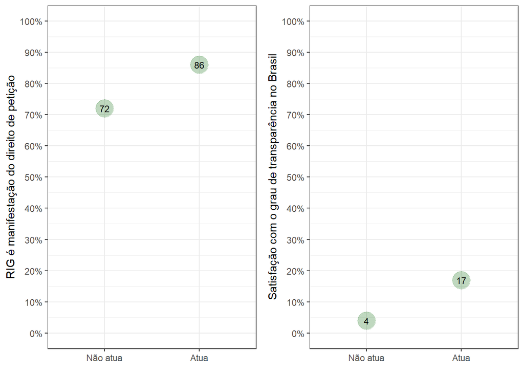

#### 1.2. Boxplots (categóricas ordinais)

As imagens abaixo ilustram a distribuição das respostas para as variáveis em foco. Cada pontinho representa uma resposta. A variação da posição horizontal é aleatória, incluída apenas para facilitar a visualização (caso contrário, pontos em uma mesma linha iriam se sobrepor). As linhas verticais, nas extremidades superior e inferior das caixas, indicam a amplitude dos valores máximos e mínimos - observações para além dessas linhas são considerados outliers. A base da caixa demonstra o primeiro quartil; enquanto o topo representa o terceiro quartil. A linha grossa, indica a mediana. Já o valor numérico, próximo a essa linha, aponta à média. Todos esses elementos podem coincidir ou não, a depender da distribuição dos dados. Por exemplo, no primeiro boxplot da segunda linha, as respostas estão bem concentradas; logo, valores mínimo e máximo, assim como quartis, média e mediana, ocupam basicamente o mesmo espaço.

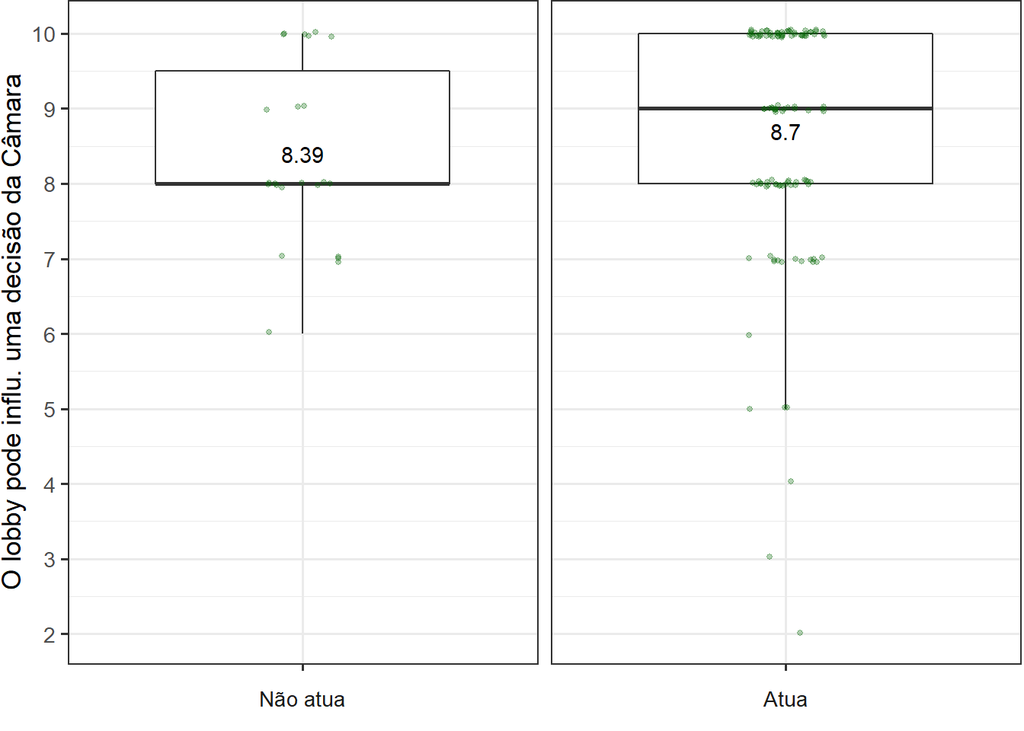

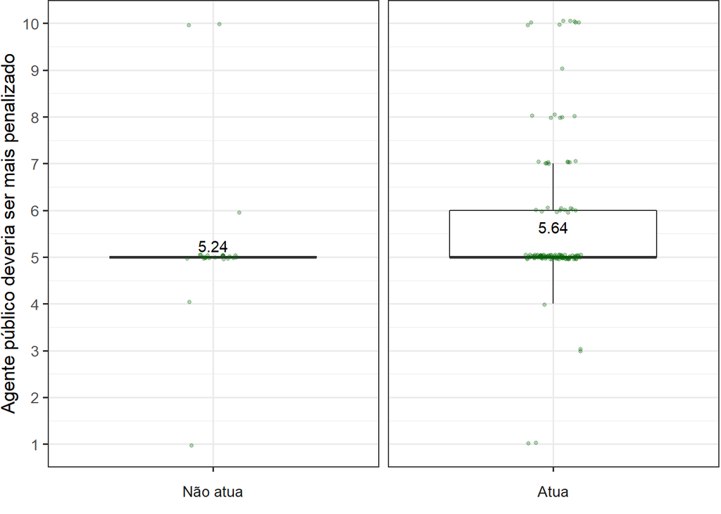

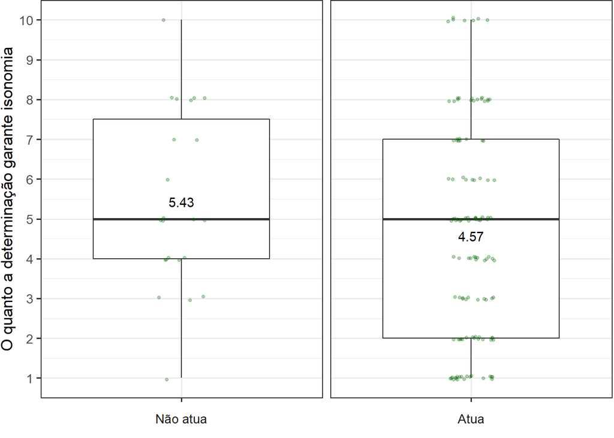

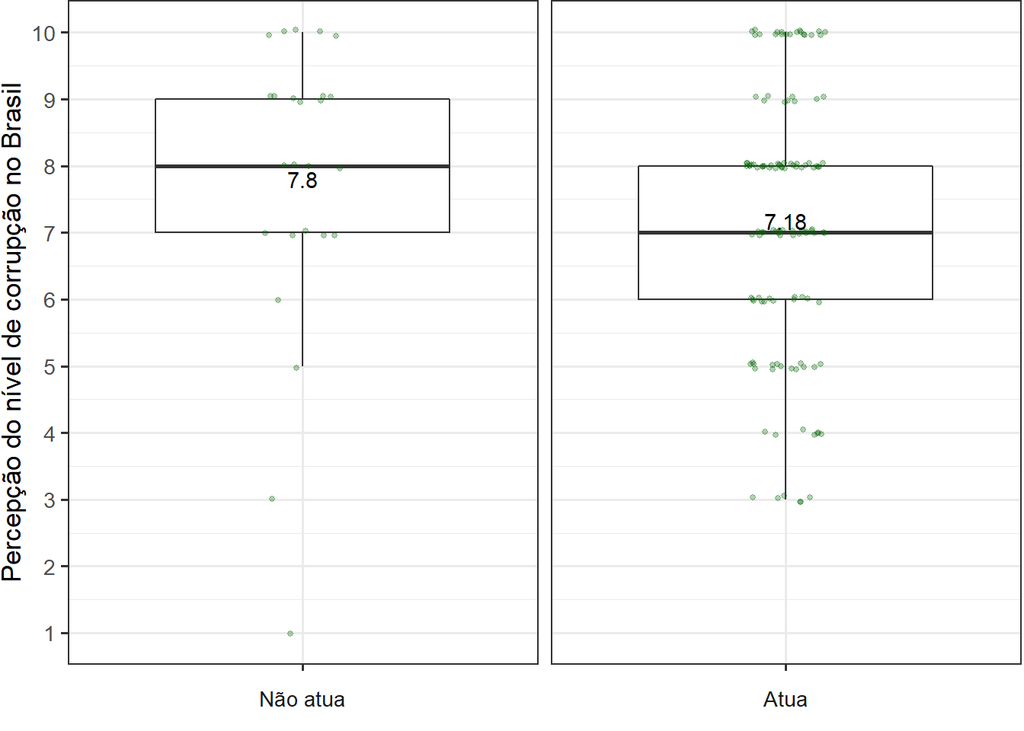

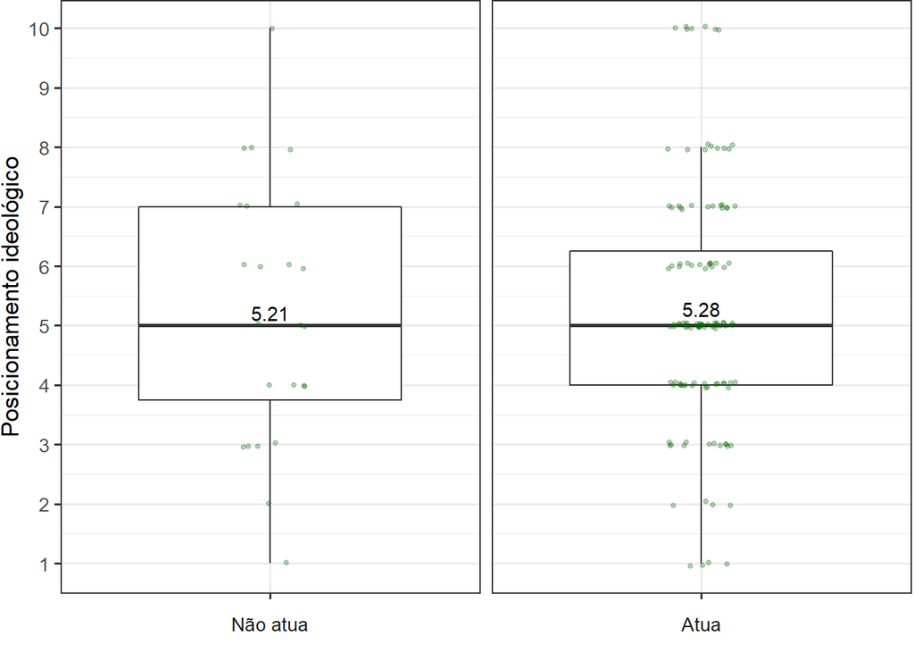

#### 1.3. Barras (categóricas nominais)

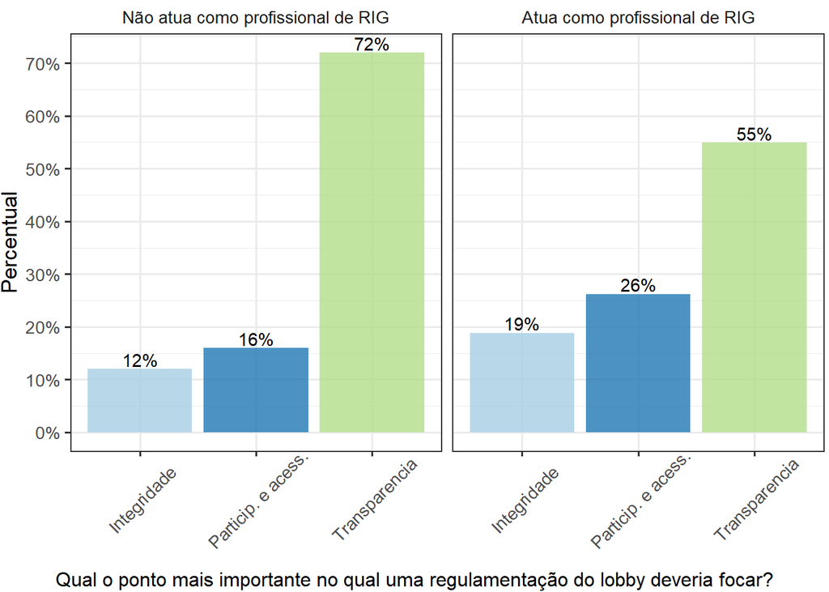

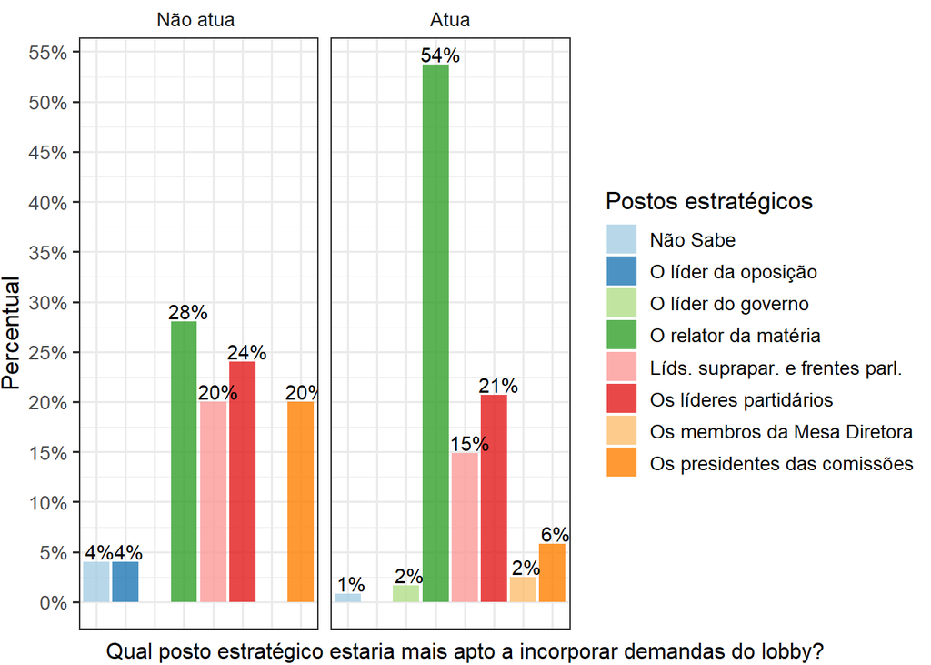

### Atua no setor privado *vs*. atua nos demais setores

#### 2.1. Diferenças de médias (binárias)

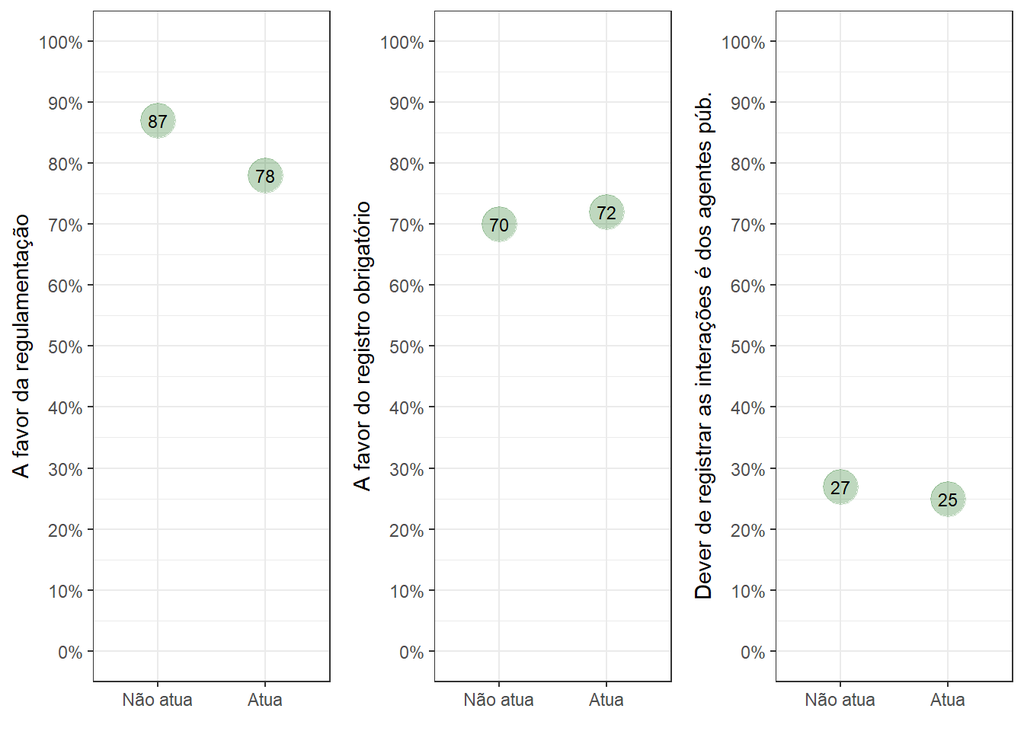

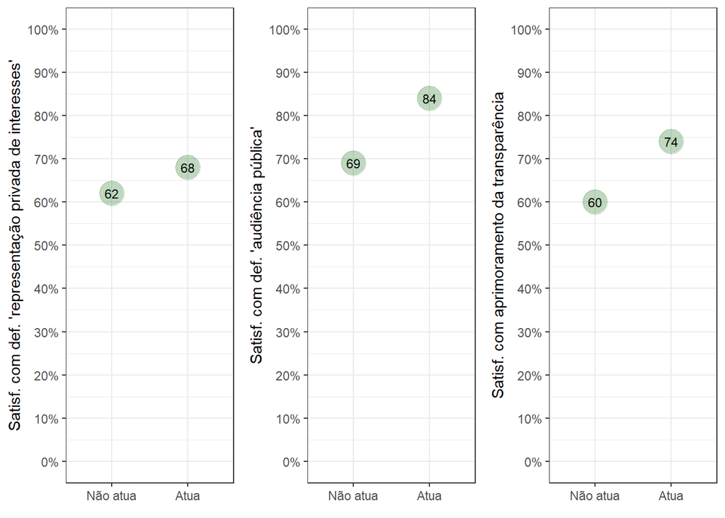

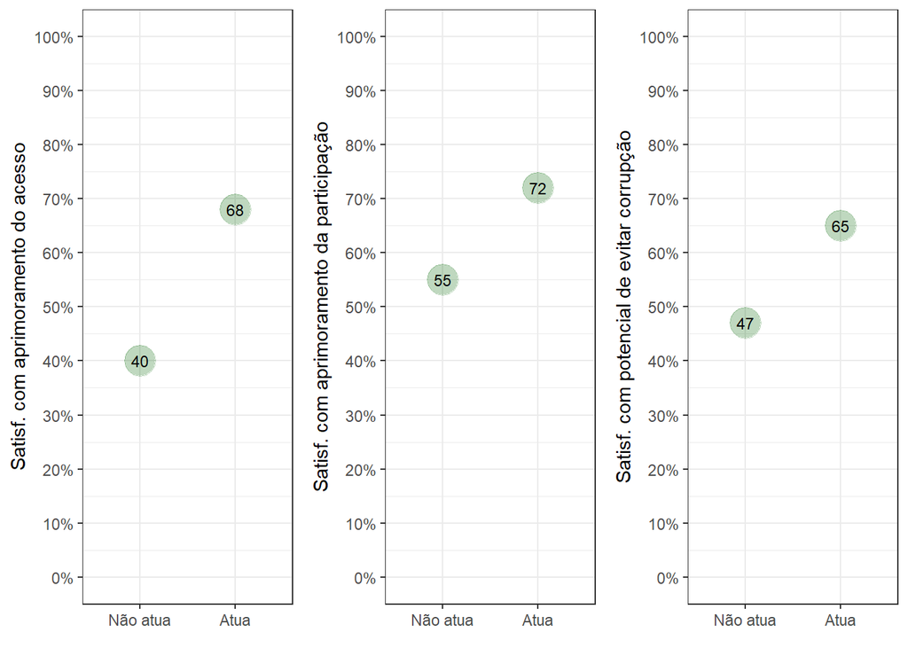

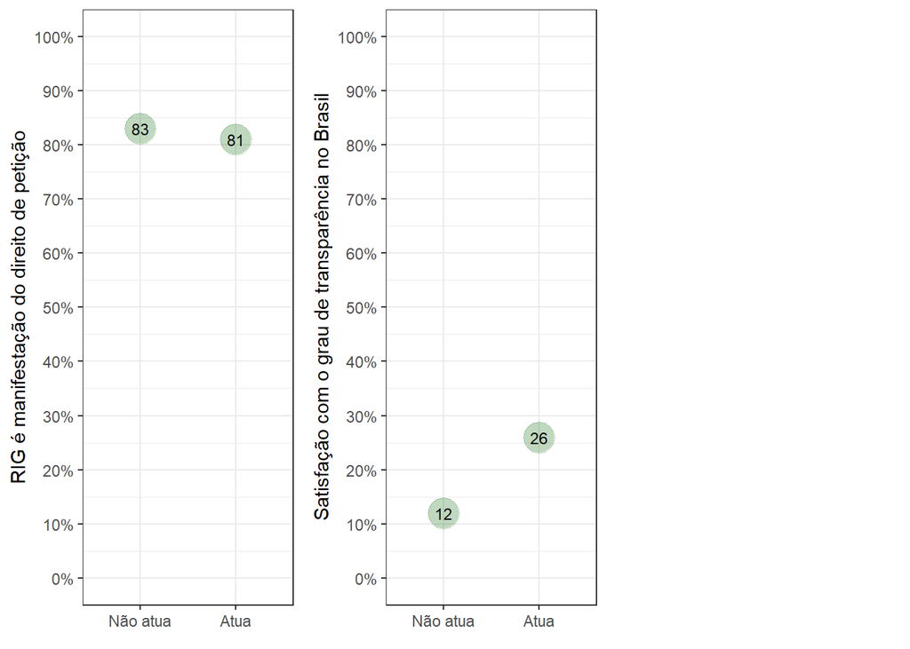

#### 2.2. Boxplots (categóricas ordinais)

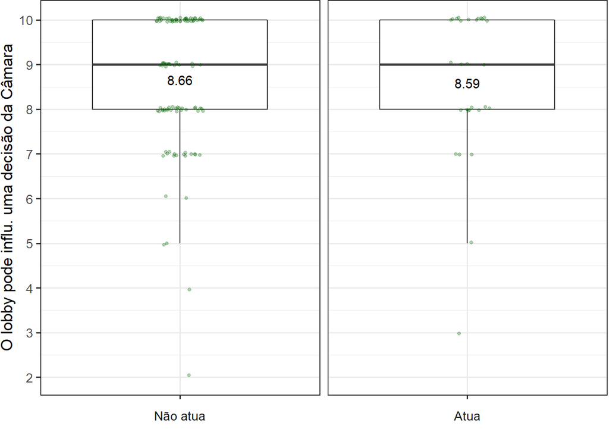

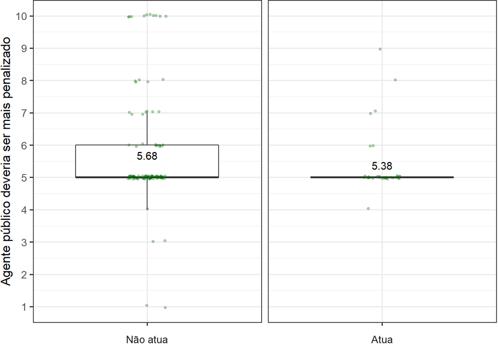

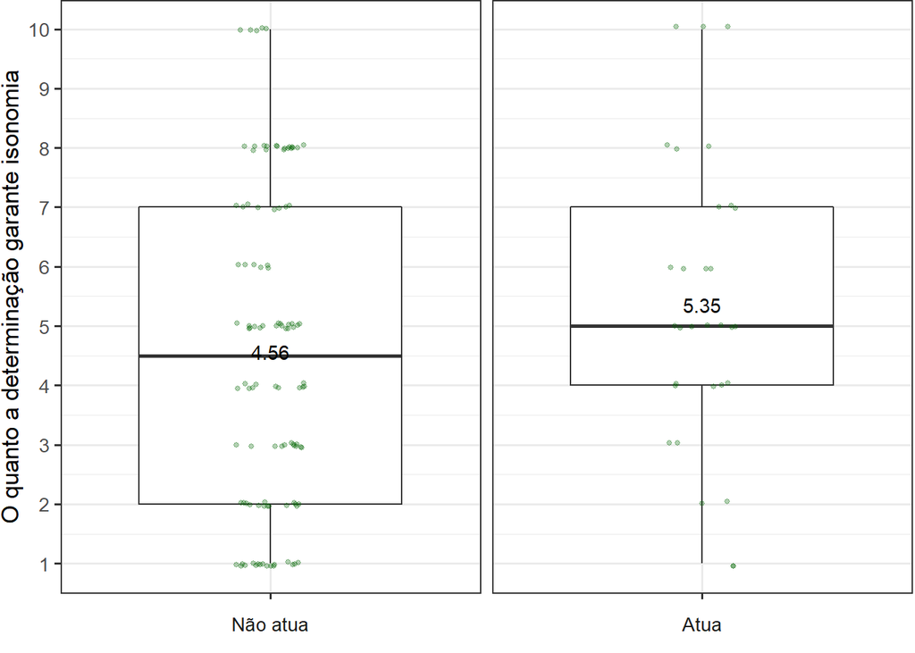

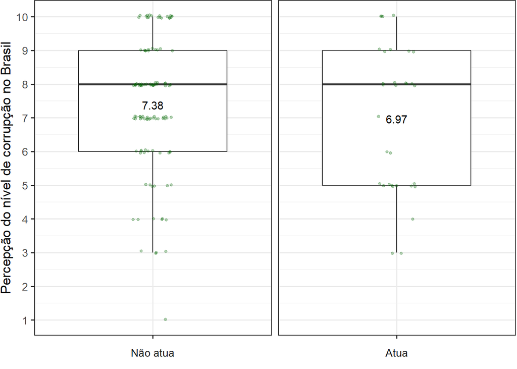

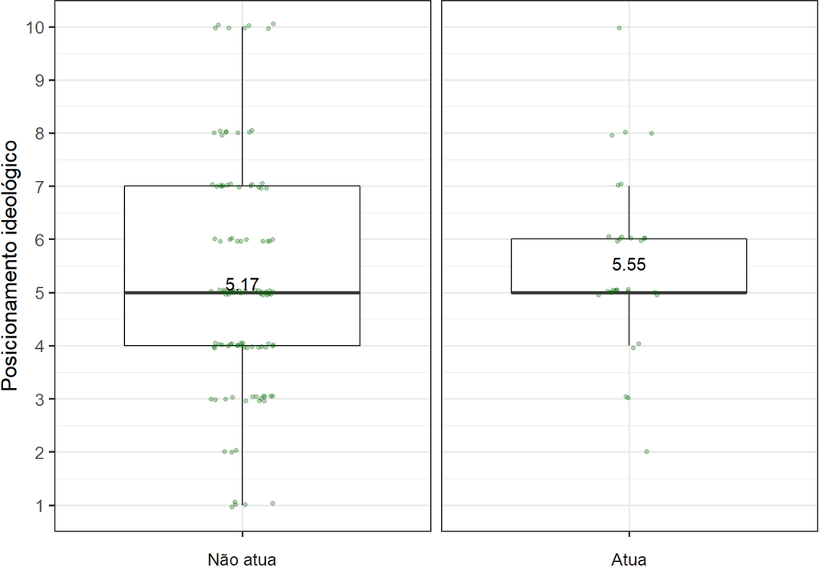

#### 2.3. Barras (categóricas nominais)

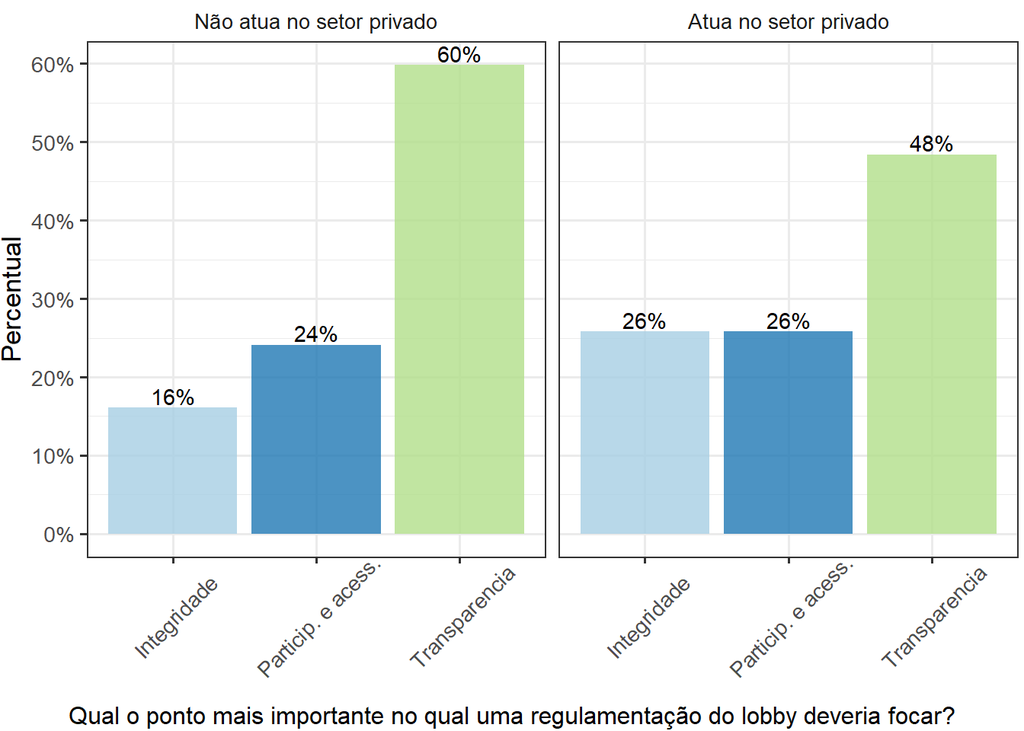

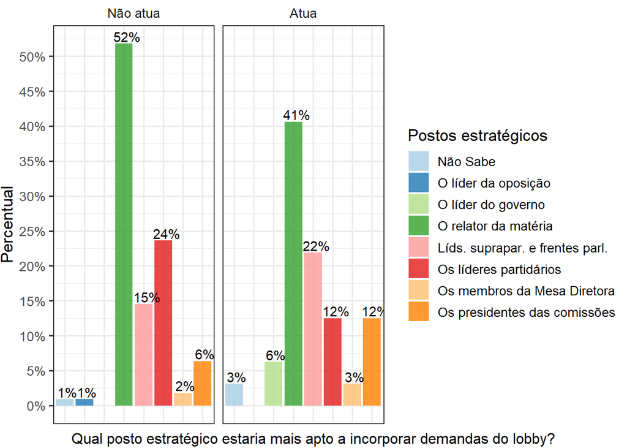

### Profissionais de RIG *vs*. deputados

#### 3.1. Diferenças de médias (binárias, exceto “idade”)

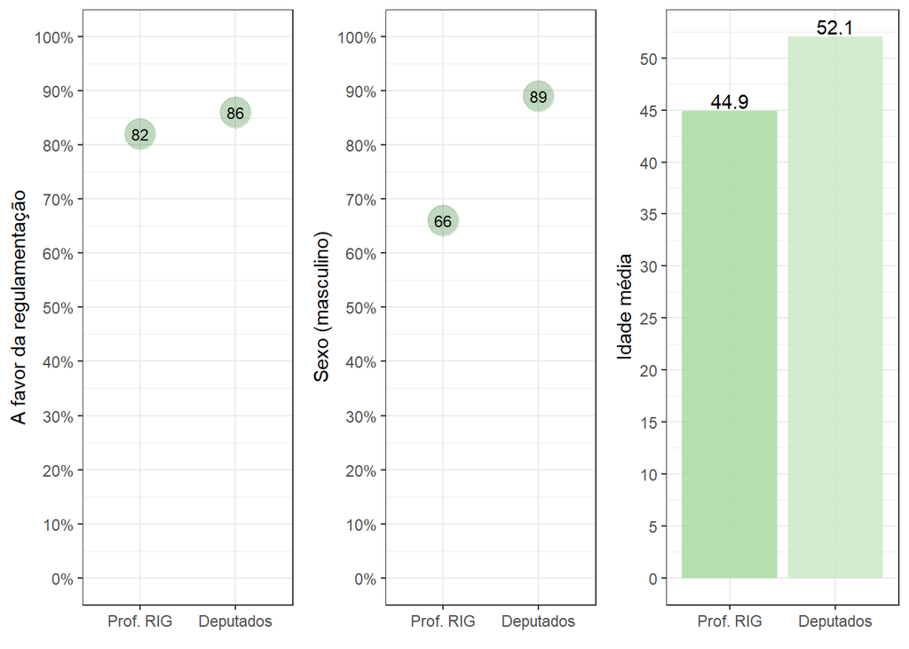

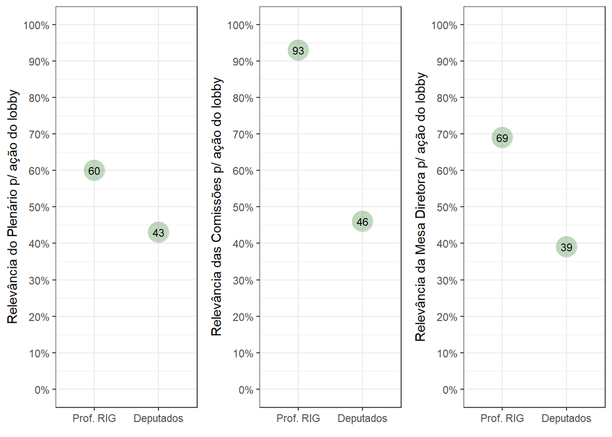

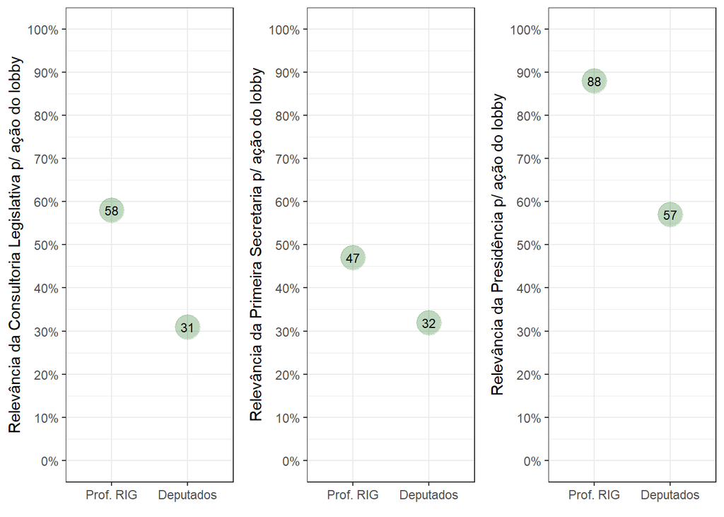

#### 3.2. Boxplots (categóricas ordinais)

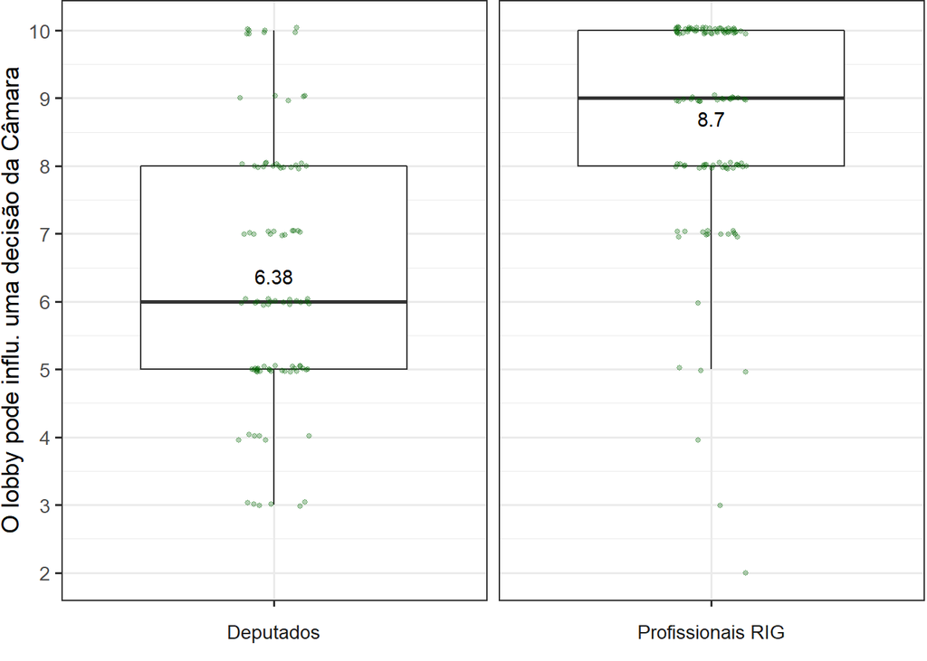

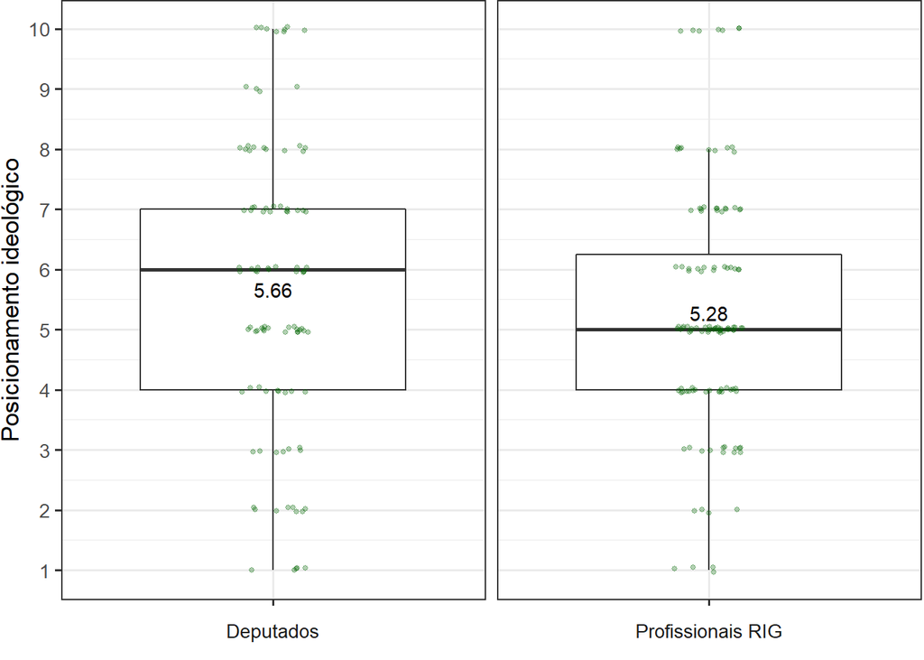

### Operacionalização das variáveis e estatísticas descritivas.

| **Variable** | **Stats / Values** | **Freqs (% of Valid)** | **Graph** | **Missing** |
| --- | --- | --- | --- | --- |
| 1. Em uma escala onde 1 significa “nenhuma influência”, e 10 significa “muita influência”, o(a) Sr(a). acha que as ações de lobby e representação de interesses podem influenciar significativamente uma… | Mean (sd) : 8.8 (1.4) min ≤ med ≤ max: 2 ≤ 9 ≤ 10 IQR (CV) : 2 (0.2) | 2 : 1 ( 0.5% ) 3 : 1 ( 0.5% ) 4 : 1 ( 0.5% ) 5 : 3 ( 1.5% ) 6 : 2 ( 1.0% ) 7 : 22 ( 10.8% ) 8 : 50 ( 24.6% ) 9 : 34 ( 16.7% ) 10 : 89 ( 43.8% ) |  | 19 (8.6%) |
| 1.bin. Binário. Maior ou igual a 8 = 1. [numeric] | Min : 0 Mean : 0.9 Max : 1 | 0 : 30 ( 14.8% ) 1 : 173 ( 85.2% ) |  | 19 (8.6%) |
| 2. Na sua percepção, qual é a relevância de cada uma das seguintes arenas para a atuação dos grupos de interesse e as ações de lobby na Câmara? O Plenário. [numeric] | Min : 0 Mean : 0.4 Max : 1 | 0 : 140 ( 64.5% ) 1 : 77 ( 35.5% ) |  | 5 (2.3%) |
| 2.1. As comissões. [numeric] | Min : 0 Mean : 0.7 Max : 1 | 0 : 55 ( 25.1% ) 1 : 164 ( 74.9% ) |  | 3 (1.4%) |
| 2.2. A mesa diretora. [numeric] | Min : 0 Mean : 0.4 Max : 1 | 0 : 131 ( 60.4% ) 1 : 86 ( 39.6% ) |  | 5 (2.3%) |
| 2.3. A consultoria legislativa. [numeric] | Min : 0 Mean : 0.3 Max : 1 | 0 : 154 ( 71.3% ) 1 : 62 ( 28.7% ) |  | 6 (2.7%) |
| 2.4. A presidência. [numeric] | Min : 0 Mean : 0.6 Max : 1 | 0 : 96 ( 44.9% ) 1 : 118 ( 55.1% ) |  | 8 (3.6%) |
| 2.5. A primeira secretaria. [numeric] | Min : 0 Mean : 0.1 Max : 1 | 0 : 183 ( 85.1% ) 1 : 32 ( 14.9% ) |  | 7 (3.2%) |
| 3. E pensando em postos estratégicos no processo decisório, qual dos listados a seguir estaria mais apto a incorporar demandas do lobby e dos grupos de interesses? [character] | 1. Nao sabe 2. O lider da oposicao 3. O lider do governo 4. O relator da materia de i 5. Os lideres das bancadas s 6. Os lideres partidarios 7. Os membros da Mesa Direto 8. Os presidentes das comiss | 3 ( 1.4% ) 1 ( 0.5% ) 4 ( 1.8% ) 109 ( 50.0% ) 29 ( 13.3% ) 48 ( 22.0% ) 5 ( 2.3% ) 19 ( 8.7% ) |  | 4 (1.8%) |
| 4. O(A) Sr(a). é a favor ou contra a regulamentação do lobby no Brasil? [character] | 1. A favor 2. Contra 3. Nao sabe | 181 ( 82.6% ) 24 ( 11.0% ) 14 ( 6.4% ) |  | 3 (1.4%) |
| 4.bin. A favor = 1. [numeric] | Min : 0 Mean : 0.8 Max : 1 | 0 : 38 ( 17.4% ) 1 : 181 ( 82.6% ) |  | 3 (1.4%) |
| 5. O(A) Sr(a). concorda que uma regulamentação do lobby deve contemplar o registro obrigatório dos(as) profissionais de relações institucionais e governamentais? [character] | 1. Nao 2. Nao sabe 3. Sim | 59 ( 26.8% ) 10 ( 4.5% ) 151 ( 68.6% ) |  | 2 (0.9%) |
| 5.bin. Sim = 1. [numeric] | Min : 0 Mean : 0.7 Max : 1 | 0 : 69 ( 31.4% ) 1 : 151 ( 68.6% ) |  | 2 (0.9%) |
| 6. Agora falando sobre o registro obrigatório das interações entre os profissionais de relações institucionais e governamentais (RIG) e os agentes públicos, sobre quem deve recair o dever de registrá-… | 1. Agentes publicos 2. Ambos 3. Nao sabe 4. Profissionais de RIG | 57 ( 26.1% ) 118 ( 54.1% ) 11 ( 5.0% ) 32 ( 14.7% ) |  | 4 (1.8%) |
| 6.bin. Agentes públicos = 1. [numeric] | Min : 0 Mean : 0.3 Max : 1 | 0 : 161 ( 73.9% ) 1 : 57 ( 26.1% ) |  | 4 (1.8%) |
| 7. Na sua opinião, em um cenário onde tanto o profissional de RIG quanto o agente público infringiram as disposições de uma lei de regulamentação do lobby, quem deve ser o mais penalizado? Em uma esca… | Mean (sd) : 5.5 (1.6) min ≤ med ≤ max: 1 ≤ 5 ≤ 10 IQR (CV) : 1 (0.3) | 1 : 5 ( 2.3% ) 2 : 2 ( 0.9% ) 3 : 2 ( 0.9% ) 4 : 3 ( 1.4% ) 5 : 149 ( 68.3% ) 6 : 20 ( 9.2% ) 7 : 13 ( 6.0% ) 8 : 10 ( 4.6% ) 9 : 1 ( 0.5% ) 10 : 13 ( 6.0% ) |  | 4 (1.8%) |
| 7.bin. Maior ou igual a 8 = 1. [numeric] | Min : 0 Mean : 0.1 Max : 1 | 0 : 194 ( 89.0% ) 1 : 24 ( 11.0% ) |  | 4 (1.8%) |
| 8. Na sua opinião, qual o ponto mais importante no qual uma regulamentação do lobby deveria focar? [character] | 1. Integridade 2. Particip. e acess. 3. Transparencia | 34 ( 15.5% ) 56 ( 25.6% ) 129 ( 58.9% ) |  | 3 (1.4%) |
| 9. Qual o seu grau de familiaridade com o PL nº 6132/1990? [character] | 1. 1 | 84 ( 100.0% ) |  | 138 (62.2%) |
| 9.1. PL nº 1202/2007. [character] | 1. 1 | 101 ( 100.0% ) |  | 121 (54.5%) |
| 9.2. PLS nº 336/2015. [character] | 1. 1 | 43 ( 100.0% ) |  | 179 (80.6%) |
| 9.3. PL nº 4391/2021. [character] | 1. 0 2. 1 | 103 ( 47.0% ) 116 ( 53.0% ) |  | 3 (1.4%) |
| 9.4. PL nº 1535/2022. [character] | 1. 1 | 82 ( 100.0% ) |  | 140 (63.1%) |
| 9.5. Não sabe. [character] | 1. 1 | 51 ( 100.0% ) |  | 171 (77.0%) |
| 10. PL nº 4391/2021. Definição de 'representação privada de interesse'. O quão satisfeito o(a) Sr(a). está com essa definição? [numeric] | Min : 0 Mean : 0.6 Max : 1 | 0 : 56 ( 36.8% ) 1 : 96 ( 63.2% ) |  | 70 (31.5%) |

Generated by summarytools 1.0.1 ([R](https://www.r-project.org/) version 4.0.5)  
2022-08-10

| **Variable** | **Stats / Values** | **Freqs (% of Valid)** | **Graph** | **Missing** |
| --- | --- | --- | --- | --- |
| 11. PL nº 4391/2021. Definição de 'audiência'. O quão satisfeito o(a) Sr(a). está com essa definição? [numeric] | Min : 0 Mean : 0.7 Max : 1 | 0 : 42 ( 27.8% ) 1 : 109 ( 72.2% ) |  | 71 (32.0%) |
| 12. Na sua opinião, a atividade de relações institucionais e governamentais é uma manifestação do direito de petição? [character] | 1. Nao 2. Nao sabe 3. Sim | 17 ( 11.0% ) 9 ( 5.8% ) 128 ( 83.1% ) |  | 68 (30.6%) |
| 12.bin. Sim = 1. [numeric] | Min : 0 Mean : 0.8 Max : 1 | 0 : 26 ( 16.9% ) 1 : 128 ( 83.1% ) |  | 68 (30.6%) |
| 13. PL nº 4391/2021. Na sua opinião, em uma escala onde 1 significa “nenhuma garantia” e 10 significa “total garantia”, o quanto as determinações do PL garantem os princípios de igualdade? [numeric] | Mean (sd) : 4.7 (2.6) min ≤ med ≤ max: 1 ≤ 5 ≤ 10 IQR (CV) : 5 (0.6) | 1 : 22 ( 14.8% ) 2 : 16 ( 10.7% ) 3 : 14 ( 9.4% ) 4 : 18 ( 12.1% ) 5 : 26 ( 17.4% ) 6 : 11 ( 7.4% ) 7 : 11 ( 7.4% ) 8 : 22 ( 14.8% ) 9 : 1 ( 0.7% ) 10 : 8 ( 5.4% ) |  | 73 (32.9%) |
| 13.bin. Maior ou igual a 8 = 1. [numeric] | Min : 0 Mean : 0.2 Max : 1 | 0 : 118 ( 79.2% ) 1 : 31 ( 20.8% ) |  | 73 (32.9%) |
| 14. PL nº 4391/2021. Qual é o seu grau de satisfação com relação à regulamentação proposta pelo PL nº 4391/2021, no referente ao seu potencial de: Aprimorar a transparência no relacionamento entre age… | 1. Insatisfeito 2. Muito insatisfeito 3. Muito satisfeito 4. Nao sabe 5. Satisfeito | 27 ( 17.8% ) 9 ( 5.9% ) 16 ( 10.5% ) 18 ( 11.8% ) 82 ( 53.9% ) |  | 70 (31.5%) |
| 14.bin. Satisfeito ou muito satisfeito = 1. [numeric] | Min : 0 Mean : 0.6 Max : 1 | 0 : 54 ( 35.5% ) 1 : 98 ( 64.5% ) |  | 70 (31.5%) |
| 14.1. PL nº 4391/2021. Diminuir a desigualdade de acesso entre os grupos de interesse aos agentes públicos? [character] | 1. Insatisfeito 2. Muito insatisfeito 3. Muito satisfeito 4. Nao sabe 5. Satisfeito | 54 ( 35.8% ) 9 ( 6.0% ) 15 ( 9.9% ) 18 ( 11.9% ) 55 ( 36.4% ) |  | 71 (32.0%) |
| 14.1.bin. Satisfeito ou muito satisfeito = 1. [numeric] | Min : 0 Mean : 0.5 Max : 1 | 0 : 81 ( 53.6% ) 1 : 70 ( 46.4% ) |  | 71 (32.0%) |
| 14.2. PL nº 4391/2021. Aumentar a participação dos grupos de interesse no processo decisório? [character] | 1. Insatisfeito 2. Muito insatisfeito 3. Muito satisfeito 4. Nao sabe 5. Satisfeito | 28 ( 18.4% ) 14 ( 9.2% ) 21 ( 13.8% ) 20 ( 13.2% ) 69 ( 45.4% ) |  | 70 (31.5%) |
| 14.2.bin. Satisfeito ou muito satisfeito = 1. [numeric] | Min : 0 Mean : 0.6 Max : 1 | 0 : 62 ( 40.8% ) 1 : 90 ( 59.2% ) |  | 70 (31.5%) |

Generated by summarytools 1.0.1 ([R](https://www.r-project.org/) version 4.0.5)  
2022-08-10

| **Variable** | **Stats / Values** | **Freqs (% of Valid)** | **Graph** | **Missing** |
| --- | --- | --- | --- | --- |
| 14.3. PL nº 4391/2021. Evitar possíveis atos de corrupção e tráfico de influência? [character] | 1. Insatisfeito 2. Muito insatisfeito 3. Muito satisfeito 4. Nao sabe 5. Satisfeito | 41 ( 27.5% ) 12 ( 8.1% ) 20 ( 13.4% ) 20 ( 13.4% ) 56 ( 37.6% ) |  | 73 (32.9%) |
| 14.3.bin. Satisfeito ou muito satisfeito = 1. [numeric] | Min : 0 Mean : 0.5 Max : 1 | 0 : 73 ( 49.0% ) 1 : 76 ( 51.0% ) |  | 73 (32.9%) |
| 14.4.total. Satisfeito ou muito satisfeito com 14., 14.1., 14.2. e 14.3. = 1. [numeric] | 1 distinct value | 0 : 153 ( 100.0% ) |  | 69 (31.1%) |
| 15. Sobre o nível de transparência das instituições e do processo decisório no Brasil, o quão satisfeito(a) o(a) Sr(a). está? [character] | 1. Insatisfeito 2. Muito insatisfeito 3. Muito satisfeito 4. Satisfeito | 93 ( 61.2% ) 37 ( 24.3% ) 4 ( 2.6% ) 18 ( 11.8% ) |  | 70 (31.5%) |
| 15.bin. Satisfeito ou muito satisfeito = 1. [numeric] | Min : 0 Mean : 0.1 Max : 1 | 0 : 130 ( 85.5% ) 1 : 22 ( 14.5% ) |  | 70 (31.5%) |
| 16. Em uma escala onde 1 significa “nenhuma corrupção”, e 10 significa “muita corrupção”, como o(a) Sr(a). percebe o nível de corrupção no Brasil? [numeric] | Mean (sd) : 7.3 (2) min ≤ med ≤ max: 1 ≤ 8 ≤ 10 IQR (CV) : 3 (0.3) | 1 : 1 ( 0.7% ) 3 : 7 ( 4.6% ) 4 : 7 ( 4.6% ) 5 : 15 ( 9.8% ) 6 : 14 ( 9.2% ) 7 : 28 ( 18.3% ) 8 : 37 ( 24.2% ) 9 : 18 ( 11.8% ) 10 : 26 ( 17.0% ) |  | 69 (31.1%) |
| 16.bin. Maior ou igual a 8 = 1. [numeric] | Min : 0 Mean : 0.5 Max : 1 | 0 : 72 ( 47.1% ) 1 : 81 ( 52.9% ) |  | 69 (31.1%) |
| 17.extrema.direita. Maior ou igual a 8 = 1. [numeric] | Min : 0 Mean : 0.1 Max : 1 | 0 : 128 ( 85.9% ) 1 : 21 ( 14.1% ) |  | 73 (32.9%) |
| 18. Atua como profissional de relações institucionais e governamentais? [numeric] | Min : 0 Mean : 0.8 Max : 1 | 0 : 25 ( 16.9% ) 1 : 123 ( 83.1% ) |  | 74 (33.3%) |
| 19. A quantos anos? [numeric] | Mean (sd) : 13.1 (9) min ≤ med ≤ max: 1 ≤ 11 ≤ 45 IQR (CV) : 15 (0.7) | 27 distinct values |  | 99 (44.6%) |
| 20. Em que setor(es) o(a) Sr(a). atua como profissional de relações institucionais e governamentais? (Múltipla escolha). Setor privado. [numeric] | Min : 0 Mean : 0.5 Max : 1 | 0 : 78 ( 54.2% ) 1 : 66 ( 45.8% ) |  | 78 (35.1%) |
| 20.bin. Somente no setor privado, e mais nenhum outro = 1. [numeric] | Min : 0 Mean : 0.2 Max : 1 | 0 : 112 ( 77.8% ) 1 : 32 ( 22.2% ) |  | 78 (35.1%) |
| 20.1. Escritórios de advocacia. [numeric] | Min : 0 Mean : 0.1 Max : 1 | 0 : 130 ( 90.3% ) 1 : 14 ( 9.7% ) |  | 78 (35.1%) |
| 20.2. Consultorias. [numeric] | Min : 0 Mean : 0.4 Max : 1 | 0 : 93 ( 64.6% ) 1 : 51 ( 35.4% ) |  | 78 (35.1%) |
| 20.3. Associações (setoriais ou de classe). [numeric] | Min : 0 Mean : 0.3 Max : 1 | 0 : 107 ( 74.3% ) 1 : 37 ( 25.7% ) |  | 78 (35.1%) |
| 20.4. Organizações da sociedade civil. [numeric] | Min : 0 Mean : 0.2 Max : 1 | 0 : 117 ( 81.2% ) 1 : 27 ( 18.8% ) |  | 78 (35.1%) |
| 20.5. Institutos. [numeric] | Min : 0 Mean : 0.1 Max : 1 | 0 : 129 ( 89.6% ) 1 : 15 ( 10.4% ) |  | 78 (35.1%) |
| 20.6. Fundações. [numeric] | Min : 0 Mean : 0 Max : 1 | 0 : 138 ( 95.8% ) 1 : 6 ( 4.2% ) |  | 78 (35.1%) |
| 20.7. Think tanks. [numeric] | Min : 0 Mean : 0.1 Max : 1 | 0 : 136 ( 94.4% ) 1 : 8 ( 5.6% ) |  | 78 (35.1%) |
| 20.8. Sindicatos (patronais ou trabalhadores). [numeric] | Min : 0 Mean : 0.1 Max : 1 | 0 : 135 ( 93.8% ) 1 : 9 ( 6.2% ) |  | 78 (35.1%) |
| 20.9. Não se aplica. [numeric] | Min : 0 Mean : 0.1 Max : 1 | 0 : 128 ( 88.9% ) 1 : 16 ( 11.1% ) |  | 78 (35.1%) |
| 21. O(A) Sr(a). é associado(a) a alguma das seguintes instituições? Associação Brasileira de Comunicação Empresarial (Aberje). [character] | 1. Associacao Brasileira de | 9 ( 100.0% ) |  | 213 (95.9%) |
| 21.1. Associação Brasileira de Relações Institucionais e Governamentais (Abrig). [character] | 1. Associacao Brasileira de | 39 ( 100.0% ) |  | 183 (82.4%) |
| 21.2. Instituto Ethos. [character] | 1. Instituto Ethos | 2 ( 100.0% ) |  | 220 (99.1%) |
| 21.3. Instituto de Relações Governamentais (IRELGOV). [character] | 1. Instituto de Relacoes Gov | 39 ( 100.0% ) |  | 183 (82.4%) |
| 21.4. Rede de Advocacy Colaborativo (RAC). [character] | 1. Rede de Advocacy Colabora | 11 ( 100.0% ) |  | 211 (95.0%) |
| 21.5. Não sabe. [character] | All NA's |  |  | 222 (100.0%) |
| 21.6. Outros. [character] | 1. Advocacy Hub 2. Amcham 3. Assespro Pr 4. Conselho Federal de Relac 5. Inadec instituto naciona 6. Mulheres RelGov+ 7. Nao 8. Nao sou associado 9. Nao sou Associado a nenhu 10. OAB | 1 ( 7.1% ) 1 ( 7.1% ) 1 ( 7.1% ) 1 ( 7.1% ) 1 ( 7.1% ) 1 ( 7.1% ) 4 ( 28.6% ) 1 ( 7.1% ) 1 ( 7.1% ) 2 ( 14.3% ) |  | 208 (93.7%) |
| 22. Educação. [character] | 1. Posgraduacao completa 2. Posgraduacao incompleta 3. Superior completo 4. Superior incompleto | 113 ( 75.3% ) 9 ( 6.0% ) 25 ( 16.7% ) 3 ( 2.0% ) |  | 72 (32.4%) |
| Sexo [character] | 1. Feminino 2. Masculino | 53 ( 35.6% ) 96 ( 64.4% ) |  | 73 (32.9%) |
| Idade [numeric] | Mean (sd) : 45.2 (12.4) min ≤ med ≤ max: 21 ≤ 44.5 ≤ 81 IQR (CV) : 18.8 (0.3) | 48 distinct values |  | 76 (34.2%) |

Generated by summarytools 1.0.1 ([R](https://www.r-project.org/) version 4.0.5)  
2022-08-10